# Bank_Marketing

Data Prediction has been carried out with respect to the original data and standardized dataset.

```r
#Prediction - Original data
bank.test$predSub <- predict.glm(bank.glm, newdata = bank.test, type = "response")
headTail(bank.test)
```

```
##       age          job  marital education default balance housing loan
## 1      58   management  married  tertiary      no    2143     yes   no
## 2      44   technician   single secondary      no      29     yes   no
## 3      33 entrepreneur  married secondary      no       2     yes  yes
## 4      47  blue-collar  married   unknown      no    1506     yes   no
## ...   ...         <NA>     <NA>      <NA>    <NA>     ...    <NA> <NA>
## 45200  34  blue-collar   single secondary      no    1475     yes   no
## 45204  23      student   single  tertiary      no     113      no   no
## 45208  71      retired divorced   primary      no    1729      no   no
## 45209  72      retired  married secondary      no    5715      no   no
##        contact day month duration campaign pdays previous poutcome    y
## 1      unknown   5   may      261        1    -1        0  unknown   no
## 2      unknown   5   may      151        1    -1        0  unknown   no
## 3      unknown   5   may       76        1    -1        0  unknown   no
## 4      unknown   5   may       92        1    -1        0  unknown   no
```

[output cut: 35 more lines]

```r
#Prediction - Standardized data
bank.test$predSub1 <- predict.glm(bank.glm1, newdata = bank.test, type = "response")
headTail(bank.test)
```

```
##       age          job  marital education default balance housing loan
## 1      58   management  married  tertiary      no    2143     yes   no
## 2      44   technician   single secondary      no      29     yes   no
## 3      33 entrepreneur  married secondary      no       2     yes  yes
## 4      47  blue-collar  married   unknown      no    1506     yes   no
## ...   ...         <NA>     <NA>      <NA>    <NA>     ...    <NA> <NA>
## 45200  34  blue-collar   single secondary      no    1475     yes   no
## 45204  23      student   single  tertiary      no     113      no   no
## 45208  71      retired divorced   primary      no    1729      no   no
## 45209  72      retired  married secondary      no    5715      no   no
##        contact day month duration campaign pdays previous poutcome    y
## 1      unknown   5   may      261        1    -1        0  unknown   no
## 2      unknown   5   may      151        1    -1        0  unknown   no
## 3      unknown   5   may       76        1    -1        0  unknown   no
## 4      unknown   5   may       92        1    -1        0  unknown   no
```

[output cut: 35 more lines]

INFERENCES FROM LOGISTIC REGRESSION OF IMBALANCED DATA

```r
#Confusion Matrix - Original data
library(SDMTools)
confusion.matrix(bank.test$ObsY, bank.test$predSub, threshold = 0.5)
```

```
##     obs
## pred     0    1
##    0 19491 1743
##    1   470  901
## attr(,"class")
## [1] "confusion.matrix"
```

```r
accuracy(bank.test$ObsY, bank.test$predSub, threshold = 0.5)
```

```
##   threshold       AUC omission.rate sensitivity specificity prop.correct
## 1       0.5 0.6586128     0.6592284   0.3407716   0.9764541    0.9021013
##      Kappa
## 1 0.400966
```

```r
#Confusion Matrix - Standarized data
library(SDMTools)
confusion.matrix(bank.test$ObsY, bank.test$predSub1, threshold = 0.5)
```

```
##     obs
## pred     0    1
##    0 19396 1694
##    1   565  950
## attr(,"class")
## [1] "confusion.matrix"
```

```r
accuracy(bank.test$ObsY, bank.test$predSub1, threshold = 0.5)
```

```
##   threshold       AUC omission.rate sensitivity specificity prop.correct
## 1       0.5 0.6654994     0.6406959   0.3593041   0.9716948    0.9000664
##       Kappa
## 1 0.4062443
```

```r
#ROC Curve - Original data
library(pROC)
myROC <- roc(bank.test$y, bank.test$predSub)
myROC
```

```
##
## Call:
## roc.default(response = bank.test$y, predictor = bank.test$predSub)
##
## Data: bank.test$predSub in 19961 controls (bank.test$y no) < 2644 cases (bank.test$y yes).
## Area under the curve: 0.9059
```

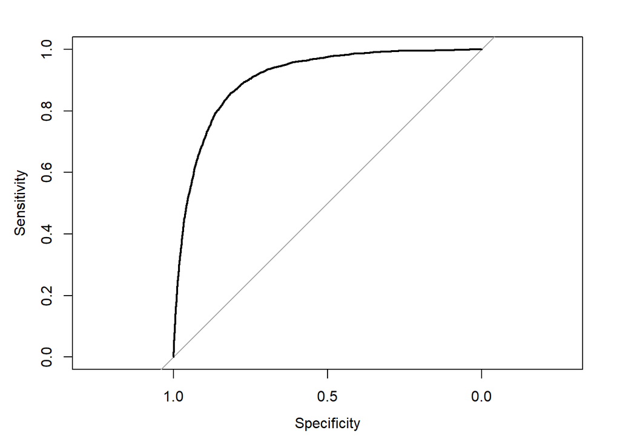

```r
plot(myROC)
```

```r
#ROC Curve - Standarized data
library(pROC)
myROC1 <- roc(bank.test$y, bank.test$predSub1)
myROC1
```

```
##
## Call:
## roc.default(response = bank.test$y, predictor = bank.test$predSub1)
##
## Data: bank.test$predSub1 in 19961 controls (bank.test$y no) < 2644 cases (bank.test$y yes).
## Area under the curve: 0.9086
```

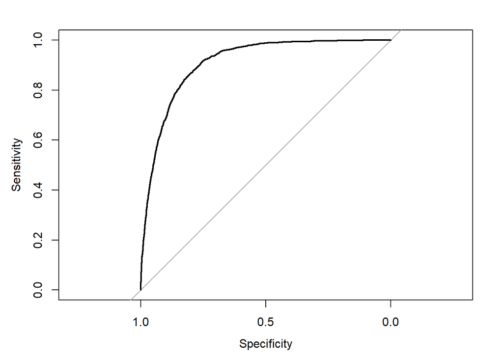

```r
plot(myROC1)
```

AUC of Standardized data is better at 90.86% when compared to the original data 90.59%

Optimum Threshold: To find the optimal threshold, I created a plot from the ROC attributes - Sensitivity, Specificity and Threshold. The point where both Sensitivity and Specificity are intersecting, the corresponding threshold is the optimum.

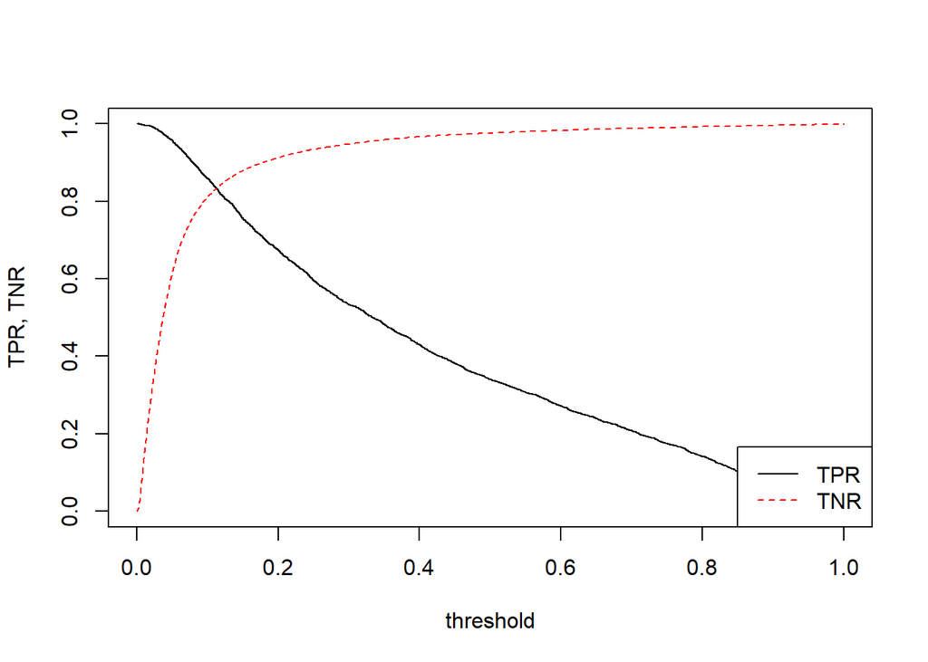

```r
# look at TPR (Sensitivity) and TNR (Specificity) distribution over threshold for Original data
matplot(data.frame(myROC$sensitivities, myROC$specificities), x = myROC$thresholds, type='l', xlab = 'threshold', ylab='TPR, TNR')
legend('bottomright', legend=c('TPR', 'TNR'), lty=1:2, col=1:2)
```

```r
# Confusion matrix for Original data with Optimal threshold of 0.1
confusion.matrix(bank.test$ObsY, bank.test$predSub, threshold = 0.1)
```

```
##     obs
## pred     0    1
##    0 16184  372
##    1  3777 2272
## attr(,"class")
## [1] "confusion.matrix"
```

```r
accuracy(bank.test$ObsY, bank.test$predSub,0.10)
```

```
##   threshold       AUC omission.rate sensitivity specificity prop.correct
## 1       0.1 0.8350426     0.1406959   0.8593041    0.810781    0.8164565
##       Kappa
## 1 0.4299222
```

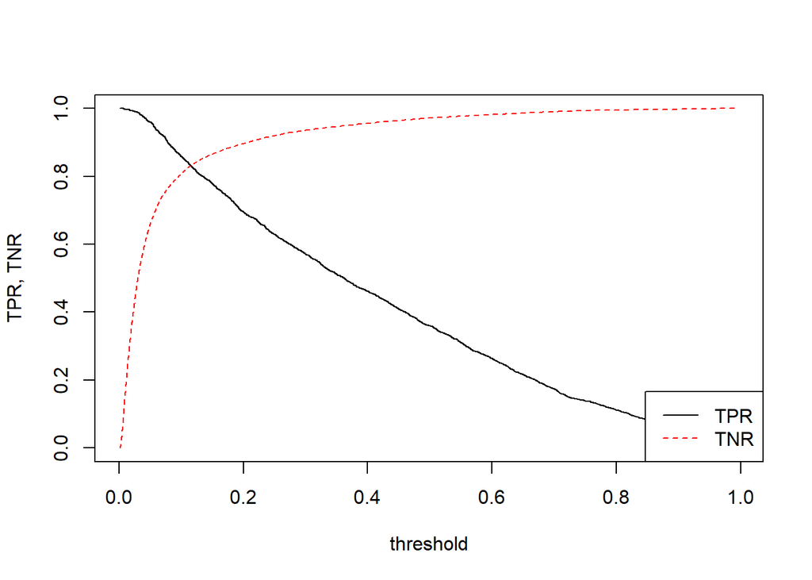

```r
# look at TPR (Sensitivity) and TNR (Specificity) distribution over threshold for Standardized data
matplot(data.frame(myROC1$sensitivities, myROC1$specificities), x = myROC1$thresholds, type='l', xlab = 'threshold', ylab='TPR, TNR')
legend('bottomright', legend=c('TPR', 'TNR'), lty=1:2, col=1:2)
```

```r
# Confusion matrix for Standardized data with Optimal threshold of 0.1
confusion.matrix(bank.test$ObsY, bank.test$predSub1, threshold = 0.1)
```

```
##     obs
## pred     0    1
##    0 16127  374
##    1  3834 2270
## attr(,"class")
## [1] "confusion.matrix"
```

```r
accuracy(bank.test$ObsY, bank.test$predSub1,0.1)
```

```
##   threshold       AUC omission.rate sensitivity specificity prop.correct
## 1       0.1 0.8332366     0.1414523   0.8585477   0.8079255    0.8138465
##       Kappa
## 1 0.4251435
```

With both Standardized and Original datasets, the optimum threshold is 0.1 which means that if the probability is >0.1, we should conclude that the subscriber will subscribe to the term deposit. Sensitivity, Specificity and Accuracy are greater than 80%.

DATA BALANCING: As the dataset is imbalanced, we need to perform data balancing to improve the prediction. There are many methods available like Under Sampling, Over Sampling, SMOTE etc. For this model, I used Random Over Sampling method (ROSE) with Standardized data.

Iteration with Balancing through ROSE method for Standardized data

```r
#Random Over Sampling (ROSE) for Original data and perform Logistic Regression

library(ROSE)
#ROSE
data_rose <- ROSE(y ~ age_imp + job_level + marital_level + edu_level + default
                + balance_imp + housing + loan + contact + day
                + month_level + duration_imp + campaign_imp + pdays_imp + previous_imp
                + poutcome_level, data = bank.train, seed = 1)$data
table(data_rose$y)
```

```
##
##    no   yes
## 11372 11234
```

As we can see above, ROSE made the minority positive outcome to be equal to majority negative outcome in the train data. This can be used to perform logistic regression and predict the test data.

LOGISTIC REGRESSION OF BALANCED STANDARDIZED DATA: Logistic regression with Standardized and balanced data is performed as given below

```r
#build logistic model Balanced data
glm.rose <- glm(y ~ age_imp + job_level + marital_level + edu_level + default
                + balance_imp + housing + loan + contact + day
                + month_level + duration_imp + campaign_imp + pdays_imp + previous_imp
                + poutcome_level,data = data_rose, family = "binomial")
summary(glm.rose)
```

```
##
## Call:
## glm(formula = y ~ age_imp + job_level + marital_level + edu_level +
##     default + balance_imp + housing + loan + contact + day +
##     month_level + duration_imp + campaign_imp + pdays_imp + previous_imp +
##     poutcome_level, family = "binomial", data = data_rose)
##
## Deviance Residuals:
##     Min       1Q   Median       3Q      Max
## -3.8615  -0.6247  -0.1497   0.6465   3.0901
##
## Coefficients:
##                           Estimate Std. Error z value Pr(>|z|)
## (Intercept)              1.675e+00  1.528e-01  10.964  < 2e-16 ***
## age_imp                 -1.050e-02  1.709e-03  -6.146 7.94e-10 ***
## job_levelune_mgmt       -5.313e-01  7.480e-02  -7.103 1.22e-12 ***
## job_levelbl_en_hm_se    -7.050e-01  7.180e-02  -9.819  < 2e-16 ***
## job_levelad_sel_te_unk  -4.409e-01  7.003e-02  -6.296 3.05e-10 ***
## marital_levelSi_Di       1.792e-01  3.893e-02   4.602 4.18e-06 ***
## edu_levelter_unk         2.083e-01  4.452e-02   4.678 2.90e-06 ***
## defaultyes              -2.771e-01  1.619e-01  -1.712  0.08695 .
## balance_imp              9.738e-05  9.221e-06  10.561  < 2e-16 ***
## housingyes              -7.666e-01  3.945e-02 -19.435  < 2e-16 ***
## loanyes                 -4.643e-01  5.540e-02  -8.380  < 2e-16 ***
## contacttelephone        -1.124e-01  7.425e-02  -1.514  0.13015
## contactunknown          -1.049e+00  5.246e-02 -20.000  < 2e-16 ***
## day                     -5.683e-03  2.008e-03  -2.830  0.00465 **
## month_levelMar_Se_Oc_De  2.007e+00  7.397e-02  27.131  < 2e-16 ***
## month_levelFe_Ap         8.579e-01  5.027e-02  17.066  < 2e-16 ***
## duration_imp             5.901e-03  8.830e-05  66.825  < 2e-16 ***
## campaign_imp            -1.122e-01  9.931e-03 -11.295  < 2e-16 ***
## pdays_imp                4.114e-04  2.312e-04   1.779  0.07516 .
## previous_imp             2.451e-02  2.463e-02   0.995  0.31961
## poutcome_levelrest      -2.545e+00  9.805e-02 -25.958  < 2e-16 ***
## ---
## Signif. codes:  0 '***' 0.001 '**' 0.01 '*' 0.05 '.' 0.1 ' ' 1
##
## (Dispersion parameter for binomial family taken to be 1)
##
##     Null deviance: 31338  on 22605  degrees of freedom
## Residual deviance: 19088  on 22585  degrees of freedom
## AIC: 19130
##
## Number of Fisher Scoring iterations: 5
```

This shows that loan default, contact: telephone, pdays and previous are statistically not significant in predicting the outcome.

This logistic regression performed on the train data is used to predict the test data as given below

```r
#make predictions with Balanced data
pred.glm.rose <- predict.glm(glm.rose, newdata = bank.test, type = "response")
```

INFERENCES FROM LOGISTIC REGRESSION OF BALANCED DATA

```r
# Confusion Matrix
confusion.matrix(bank.test$ObsY, pred.glm.rose)
```

```
##     obs
## pred     0    1
##    0 16642  455
##    1  3319 2189
## attr(,"class")
## [1] "confusion.matrix"
```

```r
accuracy(bank.test$ObsY, pred.glm.rose)
```

```
##   threshold      AUC omission.rate sensitivity specificity prop.correct
## 1       0.5 0.830819     0.1720877   0.8279123   0.8337258    0.8330458
##       Kappa
## 1 0.4501356
```

Confusion Matrix shows that sensitivity, specificity and accuracy are greater than 82% and balanced. Moreover this prediction is for threshold 0.5 while the earlier model has the optimum threshold of 0.1

```r
#AUC ROSE
myROCS <-roc(bank.test$ObsY, pred.glm.rose)
myROCS
```

```
##
## Call:
## roc.default(response = bank.test$ObsY, predictor = pred.glm.rose)
##
## Data: pred.glm.rose in 19961 controls (bank.test$ObsY 0) < 2644 cases (bank.test$ObsY 1).
## Area under the curve: 0.908
```

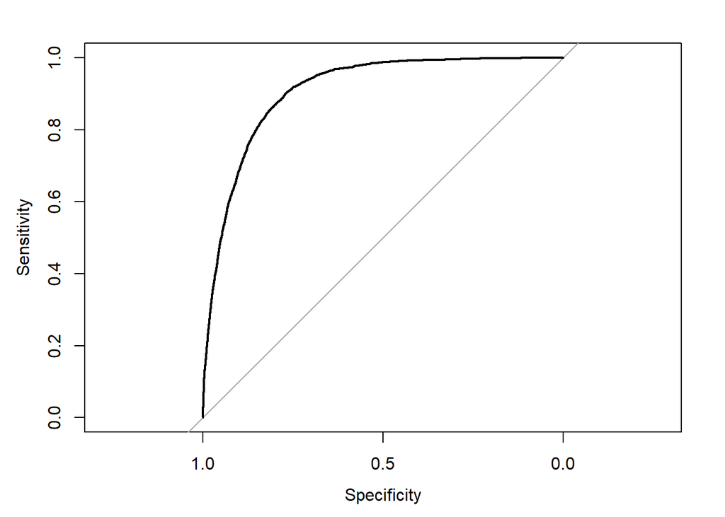

```r
plot(myROCS)
```

AUC remains same of 90.8% when compared to the earlier model

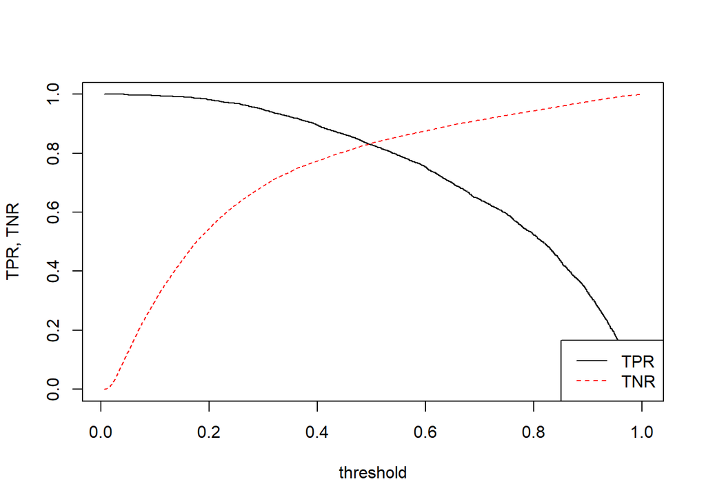

```r
# look at TPR (Sensitivity) and TNR (Specificity) distribution over threshold for Original data
matplot(data.frame(myROCS$sensitivities, myROCS$specificities), x = myROCS$thresholds, type='l', xlab = 'threshold', ylab='TPR, TNR')
legend('bottomright', legend=c('TPR', 'TNR'), lty=1:2, col=1:2)
```

The optimum threshold is 0.5 since that data is perfectly balanced. Customers with predicted probabilities greater than 0.5 will subscribe to the term deposit.

DECISION TREE FOR STANDARDIZED BALANCED DATA Since this is a classification problem, this can also be addressed through decision tree. Here I took the standardized and balanced dataset (ROSE) to create decision tree. Decision tree is created based on Recursive Partitioning algorithm (rpart).

```r
# Decision Tree for standardised data with ROSE Balancing
library(rpart)
tree.rose <- rpart(y ~., data = data_rose)
tree.rose
```

```
## n= 22606
##
## node), split, n, loss, yval, (yprob)
##       * denotes terminal node
##
##  1) root 22606 11234 no (0.5030523 0.4969477)
##    2) duration_imp< 299.0133 12482  3815 no (0.6943599 0.3056401)
##      4) poutcome_level=rest 11273  2729 no (0.7579171 0.2420829)
##        8) month_level=Ja_Ma_Ju_Jul_Au_No 8705  1251 no (0.8562895 0.1437105) *
##        9) month_level=Mar_Se_Oc_De,Fe_Ap 2568  1090 yes (0.4244548 0.5755452)
##         18) housing=yes 972   353 no (0.6368313 0.3631687) *
##         19) housing=no 1596   471 yes (0.2951128 0.7048872) *
##      5) poutcome_level=success 1209   123 yes (0.1017370 0.8982630) *
##    3) duration_imp>=299.0133 10124  2705 yes (0.2671869 0.7328131)
##      6) duration_imp< 511.7324 4562  1812 yes (0.3971942 0.6028058)
##       12) contact=unknown 709   147 no (0.7926657 0.2073343) *
##       13) contact=cellular,telephone 3853  1250 yes (0.3244225 0.6755775) *
##      7) duration_imp>=511.7324 5562   893 yes (0.1605538 0.8394462) *
```

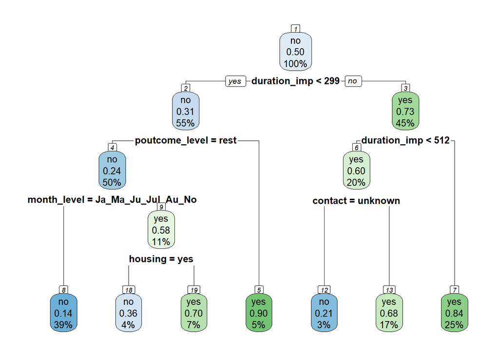

```r
library(rpart.plot)
rpart.plot(tree.rose, nn = TRUE)
```

```r
#Decision Tree Prediction
pred.tree.rose <- predict(tree.rose, newdata = bank.test)
pred.tree.rose
```

```r
#Confusion Matrix
library(SDMTools)
confusion.matrix(bank.test$ObsY, pred.tree.rose[,2])
```

```
##     obs
## pred     0    1
##    0 15393  396
##    1  4568 2248
## attr(,"class")
## [1] "confusion.matrix"
```

```r
accuracy(bank.test$ObsY, pred.tree.rose[,2])
```

```
##   threshold       AUC omission.rate sensitivity specificity prop.correct
## 1       0.5 0.8106903     0.1497731   0.8502269   0.7711537    0.7804026
##       Kappa
## 1 0.3688918
```

```r
#ROC Curve
library(pROC)
myROCD <- roc(bank.test$y, pred.tree.rose[,2])
myROCD
```

```
##
## Call:
## roc.default(response = bank.test$y, predictor = pred.tree.rose[,     2])
##
## Data: pred.tree.rose[, 2] in 19961 controls (bank.test$y no) < 2644 cases (bank.test$y yes).
## Area under the curve: 0.8448
```

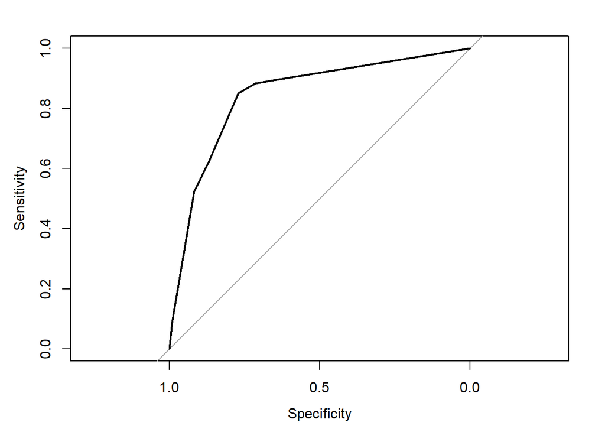

```r
plot(myROCD)
```

AUC has been decreased a lot to 84.48% when compared to the Logistic Regression.

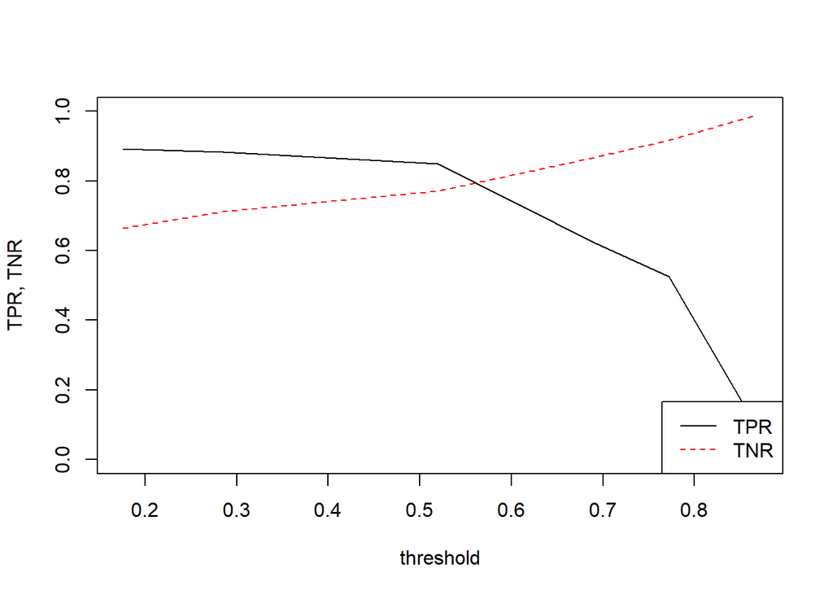

```r
# look at TPR (Sensitivity) and TNR (Specificity) distribution over threshold
matplot(data.frame(myROCD$sensitivities, myROCD$specificities), x = myROCD$thresholds, type='l', xlab = 'threshold', ylab='TPR, TNR')
legend('bottomright', legend=c('TPR', 'TNR'), lty=1:2, col=1:2)
```

```r
confusion.matrix(bank.test$ObsY, pred.tree.rose[,2], threshold = 0.55)
```

```
##     obs
## pred     0    1
##    0 15393  396
##    1  4568 2248
## attr(,"class")
## [1] "confusion.matrix"
```

```r
accuracy(bank.test$ObsY, pred.tree.rose[,2],0.55)
```

```
##   threshold       AUC omission.rate sensitivity specificity prop.correct
## 1      0.55 0.8106903     0.1497731   0.8502269   0.7711537    0.7804026
##       Kappa
## 1 0.3688918
```

The optimum threshold is found to be 0.55. The specificity still remains less than 80%.

INFERENCES ON THE MODEL: Per the extensive data analysis done using logistic regression models (with structured data, with original data, with structured and balanced data) and decision tree model (with structured and balanced data), it is inferred that the best model among these in doing the prediction is Logistic Regression with Structured and Balanced Data. The Accuracy of the model is 83% with Sensitivity of 82.79%, Specificity of 83.37% and with threshold of 0.5. Cohen’s Kappa of 0.45 shows that the model has moderate fit. AUC is good at 90.8%